# Homework 3

Ismam Ferdous

2025-09-26

# Q1

Load in the penguins dataset we used in class this week, and for each of the 4 main numeric variables of interest (bill length, bill depth, flipper length, and body mass), do the following:

- Compute and report the mean and median of each variable.
- Compute and report the sd, IQR, and range of each variable.
- Find the observations at the 10th and 90th percentiles.
- Do any of the variables exhibit significant skewness? If yes, which ones and in what direction?
- Roughly estimate the mode(s). Are any of them multimodal?

```r
library(ggplot2)

library(tibble)


penguins <- read.csv("penguins.csv")

penguins_tibble <- as_tibble(penguins)
print(penguins_tibble, n = 30)
```

```
## # A tibble: 333 × 8
##    species island    bill_length_mm bill_depth_mm flipper_length_mm body_mass_g
##    <chr>   <chr>              <dbl>         <dbl>             <int>       <int>
##  1 Adelie  Torgersen           39.1          18.7               181        3750
##  2 Adelie  Torgersen           39.5          17.4               186        3800
##  3 Adelie  Torgersen           40.3          18                 195        3250
##  4 Adelie  Torgersen           36.7          19.3               193        3450
##  5 Adelie  Torgersen           39.3          20.6               190        3650
##  6 Adelie  Torgersen           38.9          17.8               181        3625
##  7 Adelie  Torgersen           39.2          19.6               195        4675
##  8 Adelie  Torgersen           41.1          17.6               182        3200
##  9 Adelie  Torgersen           38.6          21.2               191        3800
## 10 Adelie  Torgersen           34.6          21.1               198        4400
## 11 Adelie  Torgersen           36.6          17.8               185        3700
## 12 Adelie  Torgersen           38.7          19                 195        3450
```

[output cut: 20 more lines]

```r
numeric_vars <- c("bill_length_mm", "bill_depth_mm", "flipper_length_mm", "body_mass_g")

# BILL LENGTH :

bill_length_mean <- mean(penguins$bill_length_mm, na.rm = TRUE)
bill_length_median <- median(penguins$bill_length_mm, na.rm = TRUE)
bill_length_sd <- sd(penguins$bill_length_mm, na.rm = TRUE)
bill_length_iqr <- IQR(penguins$bill_length_mm, na.rm = TRUE)
bill_length_range <- max(penguins$bill_length_mm, na.rm = TRUE) - min(penguins$bill_length_mm, na.rm = TRUE)
bill_length_p10 <- quantile(penguins$bill_length_mm, 0.10, na.rm = TRUE)
bill_length_p90 <- quantile(penguins$bill_length_mm, 0.90, na.rm = TRUE)



# BILL DEPTH
bill_depth_mean <- mean(penguins$bill_depth_mm, na.rm = TRUE)
bill_depth_median <- median(penguins$bill_depth_mm, na.rm = TRUE)
bill_depth_sd <- sd(penguins$bill_depth_mm, na.rm = TRUE)
bill_depth_iqr <- IQR(penguins$bill_depth_mm, na.rm = TRUE)
bill_depth_range <- max(penguins$bill_depth_mm, na.rm = TRUE) - min(penguins$bill_depth_mm, na.rm = TRUE)
bill_depth_p10 <- quantile(penguins$bill_depth_mm, 0.10, na.rm = TRUE)
bill_depth_p90 <- quantile(penguins$bill_depth_mm, 0.90, na.rm = TRUE)

# FLIPPER LENGTH
flipper_length_mean <- mean(penguins$flipper_length_mm, na.rm = TRUE)
flipper_length_median <- median(penguins$flipper_length_mm, na.rm = TRUE)
flipper_length_sd <- sd(penguins$flipper_length_mm, na.rm = TRUE)
flipper_length_iqr <- IQR(penguins$flipper_length_mm, na.rm = TRUE)
flipper_length_range <- max(penguins$flipper_length_mm, na.rm = TRUE) - min(penguins$flipper_length_mm, na.rm = TRUE)
flipper_length_p10 <- quantile(penguins$flipper_length_mm, 0.10, na.rm = TRUE)
flipper_length_p90 <- quantile(penguins$flipper_length_mm, 0.90, na.rm = TRUE)

# BODY MASS
body_mass_mean <- mean(penguins$body_mass_g, na.rm = TRUE)
body_mass_median <- median(penguins$body_mass_g, na.rm = TRUE)
body_mass_sd <- sd(penguins$body_mass_g, na.rm = TRUE)
body_mass_iqr <- IQR(penguins$body_mass_g, na.rm = TRUE)
body_mass_range <- max(penguins$body_mass_g, na.rm = TRUE) - min(penguins$body_mass_g, na.rm = TRUE)
body_mass_p10 <- quantile(penguins$body_mass_g, 0.10, na.rm = TRUE)
body_mass_p90 <- quantile(penguins$body_mass_g, 0.90, na.rm = TRUE)



# printing results out :


cat("BILL LENGTH")
```

```
## BILL LENGTH
```

```r
cat("Mean:", bill_length_mean)
```

```
## Mean: 43.99279
```

```r
cat("Median:", bill_length_median)
```

```
## Median: 44.5
```

```r
cat("SD:", bill_length_sd)
```

```
## SD: 5.468668
```

```r
cat("IQR:", bill_length_iqr )
```

```
## IQR: 9.1
```

```r
cat("Range:", bill_length_range )
```

```
## Range: 27.5
```

```r
cat("10th percentile:", bill_length_p10 )
```

```
## 10th percentile: 36.6
```

```r
cat("90th percentile:", bill_length_p90 )
```

```
## 90th percentile: 50.8
```

```r
cat("Skewness (mean-median)/sd:", (bill_length_mean - bill_length_median) / bill_length_sd, "\n\n")
```

```
## Skewness (mean-median)/sd: -0.09274785
```

```r
cat("BILL DEPTH\n")
```

```
## BILL DEPTH
```

```r
cat("Mean:", bill_depth_mean )
```

```
## Mean: 17.16486
```

```r
cat("Median:", bill_depth_median )
```

```
## Median: 17.3
```

```r
cat("SD:", bill_depth_sd )
```

```
## SD: 1.969235
```

```r
cat("IQR:", bill_depth_iqr )
```

```
## IQR: 3.1
```

```r
cat("Range:", bill_depth_range )
```

```
## Range: 8.4
```

```r
cat("10th percentile:", bill_depth_p10 )
```

```
## 10th percentile: 14.32
```

```r
cat("90th percentile:", bill_depth_p90 )
```

```
## 90th percentile: 19.5
```

```r
cat("Skewness (mean-median)/sd:", (bill_depth_mean - bill_depth_median) / bill_depth_sd, "\n\n")
```

```
## Skewness (mean-median)/sd: -0.06862315
```

```r
cat("FLIPPER LENGTH\n")
```

```
## FLIPPER LENGTH
```

```r
cat("Mean:", flipper_length_mean )
```

```
## Mean: 200.967
```

```r
cat("Median:", flipper_length_median )
```

```
## Median: 197
```

```r
cat("SD:", flipper_length_sd )
```

```
## SD: 14.01577
```

```r
cat("IQR:", flipper_length_iqr )
```

```
## IQR: 23
```

```r
cat("Range:", flipper_length_range )
```

```
## Range: 59
```

```r
cat("10th percentile:", flipper_length_p10 )
```

```
## 10th percentile: 185
```

```r
cat("90th percentile:", flipper_length_p90 )
```

```
## 90th percentile: 221
```

```r
cat("Skewness (mean-median)/sd:", (flipper_length_mean - flipper_length_median) / flipper_length_sd, "\n\n")
```

```
## Skewness (mean-median)/sd: 0.2830361
```

```r
cat("BODY MASS\n")
```

```
## BODY MASS
```

```r
cat("Mean:", body_mass_mean)
```

```
## Mean: 4207.057
```

```r
cat("Median:", body_mass_median )
```

```
## Median: 4050
```

```r
cat("SD:", body_mass_sd )
```

```
## SD: 805.2158
```

```r
cat("IQR:", body_mass_iqr )
```

```
## IQR: 1225
```

```r
cat("Range:", body_mass_range )
```

```
## Range: 3600
```

```r
cat("10th percentile:", body_mass_p10 )
```

```
## 10th percentile: 3300
```

```r
cat("90th percentile:", body_mass_p90 )
```

```
## 90th percentile: 5440
```

```r
cat("Skewness (mean-median)/sd:", (body_mass_mean - body_mass_median) / body_mass_sd, "\n\n")
```

```
## Skewness (mean-median)/sd: 0.1950496
```

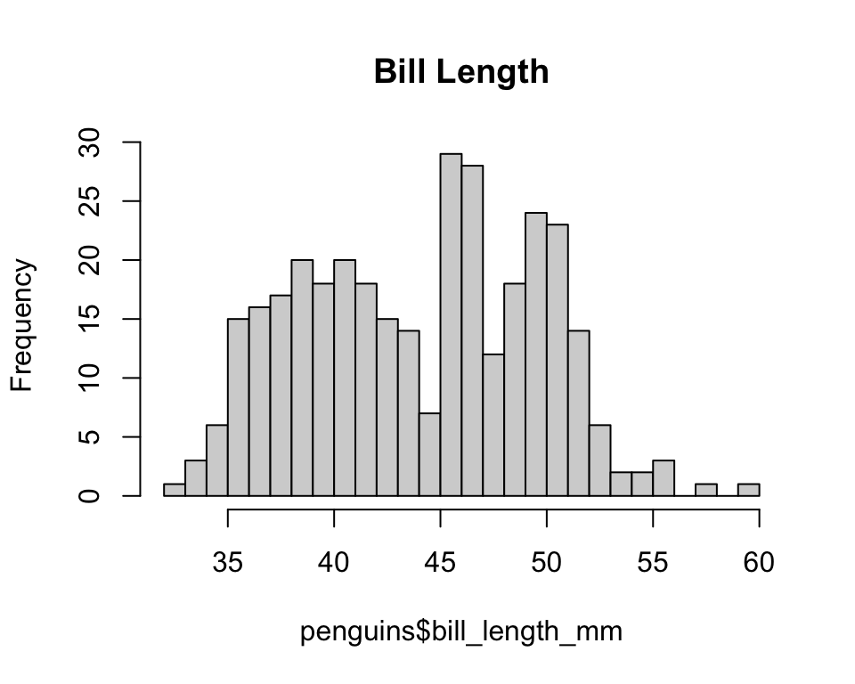

```r
# making a histogram :

hist(penguins$bill_length_mm, main = "Bill Length", breaks = 20)
```